# Determining The Odds For Cardiovascular Disaease

Using Framingham Heart Study Data

By Matthew Curcio

## 1. Executive Summary

This report investigates data from the 1948 Framingham Heart Study.[^1] Data can be found at Kaggle.[^2]

Using this data, I investigate the risk factors and odds for seven factors that increase the likelihood of cardiovascular disease (CVD).

1. This report and my article Introduction to Logit[^3] discuss ideas concerning logistic regression and R.
2. Seven (7) factors have a strong correlation that leads to cardiovascular disease. The odds related to each factor are calculated from the data.

### Seven Factors and YOUR Odds Of Developing Cardiovascular Disease

[output not shown]

## 2. Introduction

Odds are calculated by using dividing two probabilities. In the case of a *Risk of Stroke,* divide the Probability *WITH* the prevalence of stroke in a patients’ family history *VERSUS* the Probability *WITHOUT* having the prevalence of stroke in the family history.

*For Example:*

$$Odds~of~Stroke ~~=~~
\frac{Probability~[Stroke~in~family~history]}{Probability~[NO~stroke~in~family~history]}
~=~ \frac{0.18761}{0.07778} ~=~ \frac{2.41}{1}$$

This longitudinal study includes 4,133 participants with 13 factors total over 10 years.

> The Framingham Heart Study began in 1948 by recruiting 5,209 men and women between the ages of 30 and 62 from the town of Framingham, Massachusetts. [These recruits] had not yet developed overt symptoms of cardiovascular disease or suffered a heart attack or stroke.

> [The] study has since led to the identification of major CVD risk factors, as well as valuable information on the effects of these factors such as blood pressure, blood triglyceride and cholesterol levels, age, gender, and psychosocial issues.[^4]

## 3. Exploratory Data Analysis

### 3.1 Descriptive Statistics

#### 3.1.1 Age Of Participants, Cigarettes Per Day, Body Mass Index

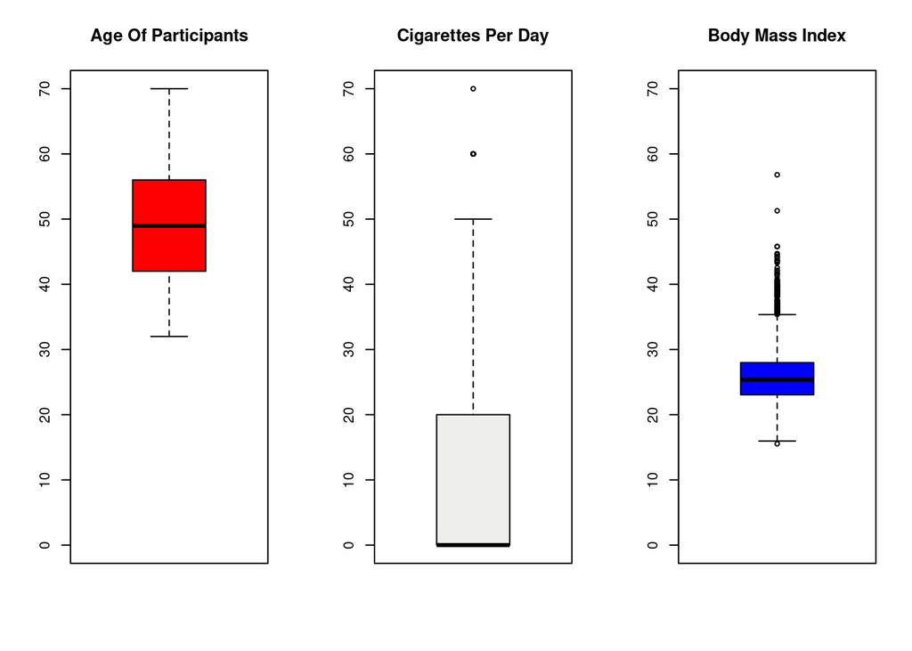

```r
par(mfrow = c(1, 3))
boxplot(df$age, ylim=c(0,70), col = "red")
title('Age Of Participants')

boxplot(df$cigsPerDay, ylim=c(0,70), col = "#EEEEEC")
title('Cigarettes Per Day')

boxplot(df$BMI, ylim=c(0,70), col = "blue")
title('Body Mass Index')
```

#### 3.1.2 Systolic Blood Pressure, Diastolic BP, Heart Rate

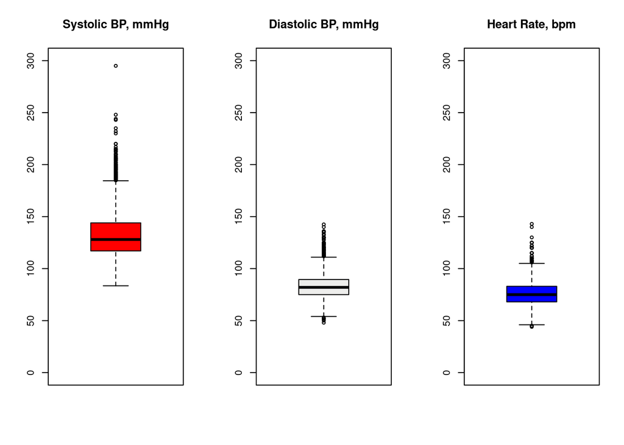

```r
par(mfrow = c(1, 3))
boxplot(df$sysBP, ylim=c(0,300), col = "red")
title('Systolic BP, mmHg')

boxplot(df$diaBP, ylim=c(0,300), col = "#EEEEEC")
title('Diastolic BP, mmHg')

boxplot(df$heartRate, ylim=c(0,300), col = "blue")
title('Heart Rate, bpm')
```

#### 3.1.3 Glucose, Cholesterol

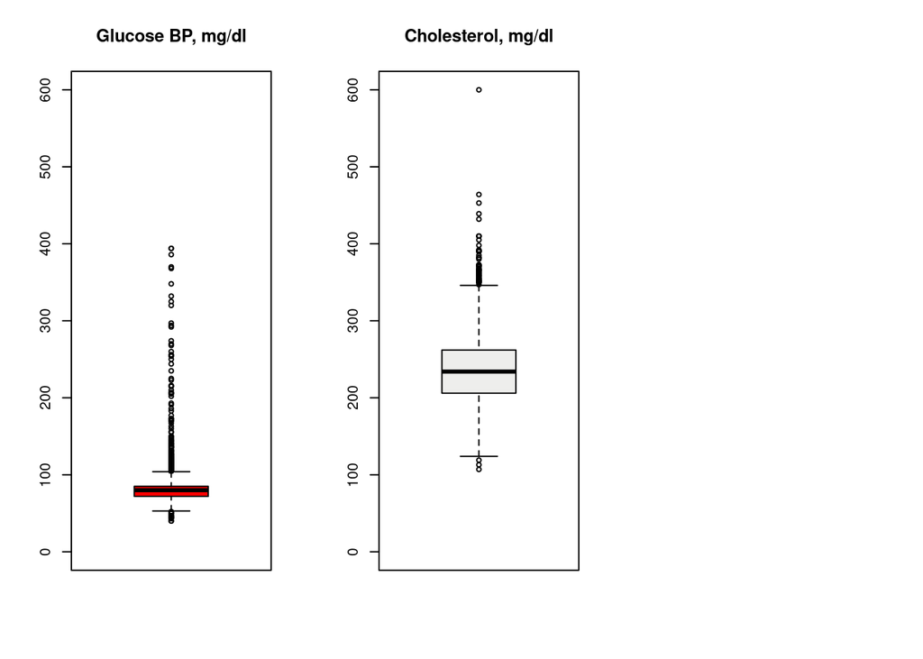

```r
par(mfrow = c(1, 3))
boxplot(df$glucose, ylim=c(0,600), col = "red")
title('Glucose BP, mg/dl')

boxplot(df$totChol, ylim=c(0,600), col = "#EEEEEC")
title('Cholesterol, mg/dl')
```

#### 3.1.3 Male and Female Participants by Age

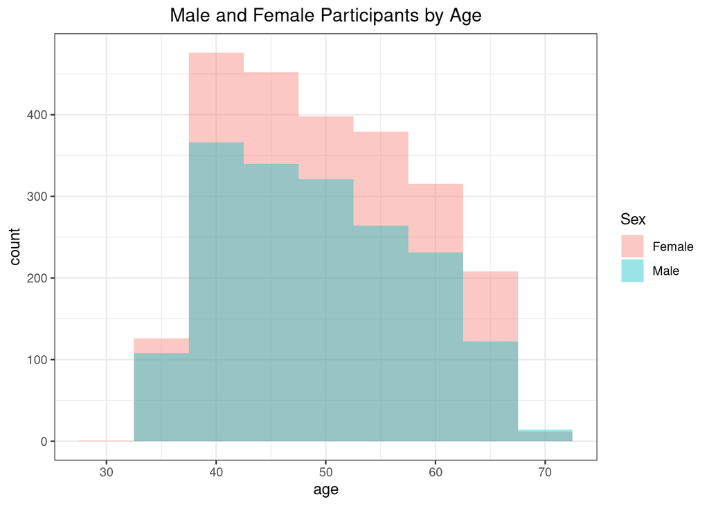

```r
# install.packages("ggplot2")
library(ggplot2)

# Histogram by group in ggplot2
ggplot(df, aes(x = age, fill = male)) +
  geom_histogram(alpha = 0.4, binwidth=5, position = "identity") +
  scale_color_discrete(labels = c("Female", "Male")) +
  scale_fill_discrete(labels = c("Female", "Male")) +
  ggtitle("Male and Female Participants by Age") +
  theme_bw() +
  theme(plot.title = element_text(hjust = 0.5)) +
  labs(fill = "Sex")
```

## 2. Logistic Regression Model Results

### 2.1 Model Using 13 Factors

```r
mylogit <- glm(TenYearCHD ~ male + age + education + cigsPerDay + glucose +
                            prevalentStroke + prevalentHyp + diabetes +
                            totChol + sysBP + diaBP + BMI + heartRate,
               data = df,
               family = "binomial")

summary(mylogit)
```

```
##
## Call:
## glm(formula = TenYearCHD ~ male + age + education + cigsPerDay +
##     glucose + prevalentStroke + prevalentHyp + diabetes + totChol +
##     sysBP + diaBP + BMI + heartRate, family = "binomial", data = df)
##
## Deviance Residuals:
##    Min      1Q  Median      3Q     Max
## -1.964  -0.596  -0.432  -0.294   2.810
##
## Coefficients:
##                  Estimate Std. Error z value Pr(>|z|)
## (Intercept)      -8.04990    0.64770  -12.43  < 2e-16 ***
## male1             0.48093    0.10163    4.73  2.2e-06 ***
## age               0.06263    0.00625   10.02  < 2e-16 ***
## education1        0.03031    0.10610    0.29    0.775
## cigsPerDay        0.02087    0.00397    5.25  1.5e-07 ***
## glucose           0.00619    0.00215    2.88    0.004 **
## prevalentStroke1  1.00721    0.43923    2.29    0.022 *
## prevalentHyp1     0.25864    0.12955    2.00    0.046 *
## diabetes1         0.24052    0.29605    0.81    0.417
## totChol           0.00184    0.00106    1.73    0.083 .
## sysBP             0.01498    0.00355    4.22  2.5e-05 ***
## diaBP            -0.00386    0.00602   -0.64    0.521
## BMI               0.00212    0.01182    0.18    0.857
## heartRate        -0.00248    0.00393   -0.63    0.528
## ---
## Signif. codes:  0 '***' 0.001 '**' 0.01 '*' 0.05 '.' 0.1 ' ' 1
##
## (Dispersion parameter for binomial family taken to be 1)
##
##     Null deviance: 3521.9  on 4132  degrees of freedom
## Residual deviance: 3131.2  on 4119  degrees of freedom
## AIC: 3159
##
## Number of Fisher Scoring iterations: 5
```

- **7 most significant variables**
- Seven predictors have $\small \alpha < 0.05$. They are significant and associated with acquiring cardiovascular disease.

| Rank | Risk Factor |
| --- | --- |
| 1 | Prevalence of Stroke1 |
| 2 | Male1 |
| 3 | Prevalence of Hypertension1 |
| 4 | Age |
| 5 | Cigarettes Per Day |
| 6 | Systolic Blood Pressure |
| 7 | Glucose |

### 2.3 Determination of Odds for Seven Variables

- We can calculate the odds of acquiring cardiovascular disease for each of the seven variables.
- By holding all other values constant we create a dataframe that investigates the odds given Prevalence of Stroke, for example.

```r
strok_test <- with(df, data.frame(male = "0",
                                  age = mean(age),
                                  education = "0",
                                  cigsPerDay = 0, # Non-smoker
                                  prevalentHyp = "0",
                                  diabetes = "0",
                                  totChol = mean(totChol),
                                  sysBP = mean(sysBP),
                                  diaBP = mean(diaBP),
                                  BMI = mean(BMI),
                                  heartRate = mean(heartRate),
                                  glucose = mean(glucose),
                                  prevalentStroke = c("0", "1"))
                   )

# Convert prevalentStroke from Numeric to FACTOR
strok_test$prevalentStroke <- as.factor(strok_test$prevalentStroke)
# str(strok_test)

strok_test$prevalentStroke <- predict(mylogit,
                                      newdata = strok_test,
                                      type = "response")
#strok_test$prevalentStroke
```

### 2.4 **Odds Given Prevalence Of Stroke In family history.**

1. WITH Prevalence of Stroke: 0.18761
2. NO Prevalence of Stroke: 0.07778
- **Odds = 2.4119**

### 2.5 **Odds Given For Male Vs Female**

```r
male_test <- with(df, data.frame(male = c("0","1"), # Factor of Interest
                                 age = mean(age),
                                 education = "0",
                                 cigsPerDay = 0,
                                 prevalentHyp = "0",
                                 diabetes = "0",
                                 totChol = mean(totChol),
                                 sysBP = mean(sysBP),
                                 diaBP = mean(diaBP),
                                 BMI = mean(BMI),
                                 heartRate = mean(heartRate),
                                 glucose = mean(glucose),
                                 prevalentStroke = "0"))

# REMEMBER convert male_test from numeric to FACTOR
male_test$male <- as.factor(male_test$male)

male_test$male <- predict(mylogit, newdata = male_test, type = "response")
```

1. Males: 0.12005
2. Female: 0.07778
- **Odds = 1.54343**

### 2.6 Odds Prevalence of Hypertension In Family History

```r
hyperT_test <- with(df, data.frame(male = "0",
                                   age = mean(age),
                                   education = "0",
                                   cigsPerDay = 0,
                                   prevalentHyp = c("0","1"), # Factor of Interest
                                   diabetes = "0",
                                   totChol = mean(totChol),
                                   sysBP = mean(sysBP),
                                   diaBP = mean(diaBP),
                                   BMI = mean(BMI),
                                   heartRate = mean(heartRate),
                                   glucose = mean(glucose),
                                   prevalentStroke = "0"))

# REMEMBER convert male_test from numeric to FACTOR
hyperT_test$prevalentHyp <- as.factor(hyperT_test$prevalentHyp)

hyperT_test$prevalentHyp <- predict(mylogit, newdata = hyperT_test, type = "response")
```

1. WITH Prevalence of Hypertension: 0.09848
2. NO Prevalence of Hypertension: 0.07778
- **Odds = 1.2661**

### 2.7 Odds Given Age

```r
age_test <- with(df, data.frame(male = "0",
                                   age = c(20,30,40,50,60,70,80),
                                   education = "0",
                                   cigsPerDay = 0,
                                   prevalentHyp = "0",
                                   diabetes = "0",
                                   totChol = mean(totChol),
                                   sysBP = mean(sysBP),
                                   diaBP = mean(diaBP),
                                   BMI = mean(BMI),
                                   heartRate = mean(heartRate),
                                   glucose = mean(glucose),
                                   prevalentStroke = "0"))

age_test$age <- predict(mylogit, newdata = age_test, type = "response")
```

| Age (years) | Probability Given Age | Odds Compared to 20 yr old |
| --- | --- | --- |
| 20 | 0.01307 | 1 |
| 30 | 0.02418 | 1.84969 |
| 40 | 0.0443 | 3.38895 |
| 50 | 0.0798 | 6.1044 |
| 60 | 0.13958 | 10.67785 |
| 70 | 0.23282 | 17.81084 |
| 80 | 0.36214 | 27.70331 |